# Which past president is Donald Trump most like?

Author: Yijia Li

# Introduction

As a well-known feature of Google, if you start typing in a search, Google offers autocomplete suggestions before you’ve even finished typing. I tried to type “Compare Trump to..”, and the top four suggestions Google gave are “Compare Trump to Nixon/Lincoln/Mussolini/Obama,” three of which are past presidents of the United States. This shows that people are most interested in comparing Trump to Nixon, Lincoln, and Obama. So, in this report, to analyze the similarities and differences between Trump and these three past presidents from a linguistic perspective, I will explore the texts of their inaugural speeches and visualize the results using text mining and natural language processing techniques. The following questions about their inaugural speeches will be answered.

1. What are their most frequently used words?
2. Do they like to use long or short sentences?
3. How do they shift between different sentiments in their speeches?
4. How do they alternate between different topics?

# 0. Data Preparation

### Step 0-1. Check and install needed packages. Load the libraries and functions.

```r
packages.used=c("rvest", "tibble", "qdap",
                "sentimentr", "gplots", "dplyr",
                "tm", "syuzhet", "factoextra",
                "beeswarm", "scales", "RColorBrewer",
                "RANN", "tm", "topicmodels","tidytext","wordcloud")

# check packages that need to be installed.
packages.needed=setdiff(packages.used,
                        intersect(installed.packages()[,1],
                                  packages.used))
# install additional packages
if(length(packages.needed)>0){
  install.packages(packages.needed, dependencies = TRUE)
}

# load packages
library("rvest")
library("tibble")
library("qdap")
library("sentimentr")
library("gplots")
library("dplyr")
library("tm")
library("syuzhet")
library("factoextra")
library("beeswarm")
library("scales")
library("RColorBrewer")
library("RANN")
library("tm")
library("topicmodels")
library("tidytext")
library("wordcloud")

source("../lib/plotstacked.R")
source("../lib/speechFuncs.R")
```

This notebook was prepared with the following environmental settings.

```r
print(R.version)
```

```
##                _
## platform       x86_64-apple-darwin13.4.0
## arch           x86_64
## os             darwin13.4.0
## system         x86_64, darwin13.4.0
## status
## major          3
## minor          3.1
## year           2016
## month          06
## day            21
## svn rev        70800
## language       R
## version.string R version 3.3.1 (2016-06-21)
## nickname       Bug in Your Hair
```

### Step 0-2. Data harvest: scrap inaugural speech URLs from http://www.presidency.ucsb.edu/.

```r
### Inauguaral speeches
main.page <- read_html(x = "http://www.presidency.ucsb.edu/inaugurals.php")
# Get link URLs
# f.speechlinks is a function for extracting links from the list of speeches.
inaug=f.speechlinks(main.page)
inaug=inaug[-nrow(inaug),] # remove the last line, irrelevant due to error.
```

### Step 0-3. Using speech metadata posted on http://www.presidency.ucsb.edu/, prepare CSV data sets for the speeches.

```r
inaug.list=read.csv("../data/inauglist.csv", stringsAsFactors = FALSE)
```

### Step 0-4. Scrap the texts of speeches from the speech URLs.

```r
inaug.list$type=rep("inaug", nrow(inaug.list))
inaug.list=cbind(inaug.list, inaug)
```

### Step 0-5. For reproducibility, save scrapped speeches into local folder as individual speech files.

```r
inaug.list$fulltext=NA
for(i in seq(nrow(inaug.list))) {
    text <- read_html(inaug.list$urls[i]) %>% # load the page
    html_nodes(".displaytext") %>% # isloate the text
    html_text() # get the text
  inaug.list$fulltext[i]=text
  # Create the file name
  filename <- paste0("../data/fulltext/",
                     inaug.list$type[i],
                     inaug.list$File[i], "-",
                     inaug.list$Term[i], ".txt")
  sink(file = filename) %>% # open file to write
  cat(text)  # write the file
  sink() # close the file
}
```

### Step 0-6. Read in the speeches.

```r
folder.path="../data/inaugurals/"
speeches=list.files(path = folder.path, pattern = "*.txt")
prex.out=substr(speeches, 6, nchar(speeches)-4)

ff.all<-Corpus(DirSource(folder.path))
```

# 1. What are their most frequently used words?

### Step 1-1. Text processing.

```r
ff.all<-tm_map(ff.all, stripWhitespace)
ff.all<-tm_map(ff.all, content_transformer(tolower))
ff.all<-tm_map(ff.all, removeWords, stopwords("english"))
ff.all<-tm_map(ff.all, removeWords, character(0))
ff.all<-tm_map(ff.all, removePunctuation)

tdm.all<-TermDocumentMatrix(ff.all)

tdm.tidy=tidy(tdm.all)

tdm.overall=summarise(group_by(tdm.tidy, term), sum(count))
```

### Step 1-2. Compute TF-IDF weighted document-term matrices for individual speeches.

```r
dtm <- DocumentTermMatrix(ff.all,
                          control = list(weighting = function(x)
                                             weightTfIdf(x,
                                                         normalize =FALSE),
                                         stopwords = TRUE))
tdm.tidy=tidy(dtm)

tdm.trump = subset(tdm.tidy,document == 'inaugDonaldJTrump-1.txt')
tdm.obama = subset(tdm.tidy,document == 'inaugBarackObama-1.txt')
tdm.nixon = subset(tdm.tidy,document == 'inaugRichardNixon-1.txt')
tdm.lincoln = subset(tdm.tidy,document == 'inaugAbrahamLincoln-1.txt')
```

### Step 1-3. Wordcloud - Visualize important words in individual speeches.

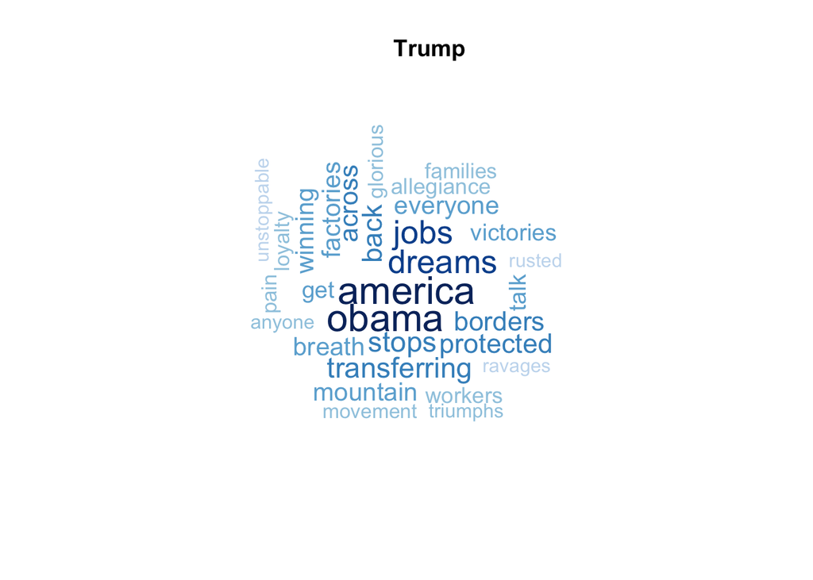

```r
wordcloud(tdm.trump$term, tdm.trump$count,
          scale=c(2,0.5),
          max.words=30,
          min.freq=1,
          random.order=FALSE,
          rot.per=0.3,
          use.r.layout=T,
          random.color=FALSE,
          colors=brewer.pal(9,"Blues"))
title(main = 'Trump')
```

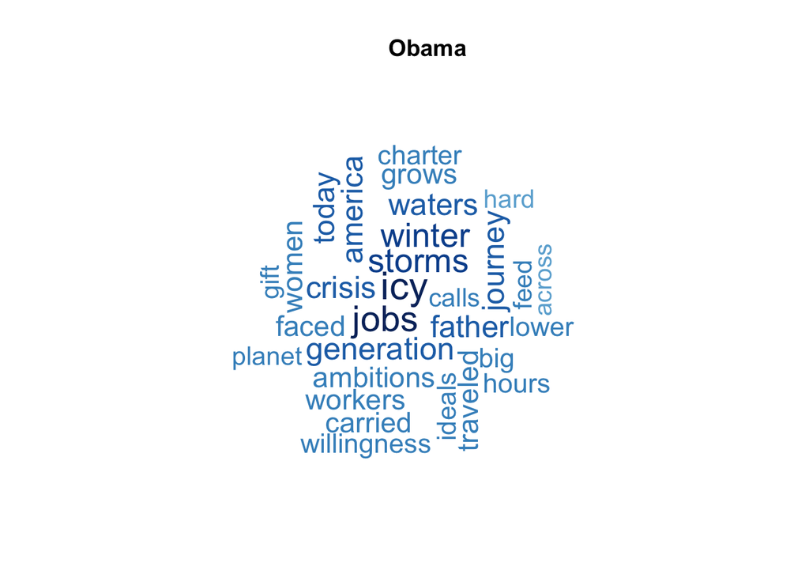

```r
wordcloud(tdm.obama$term, tdm.obama$count,
          scale=c(2,0.5),
          max.words=30,
          min.freq=1,
          random.order=FALSE,
          rot.per=0.3,
          use.r.layout=T,
          random.color=FALSE,
          colors=brewer.pal(9,"Blues"))
title(main = 'Obama')
```

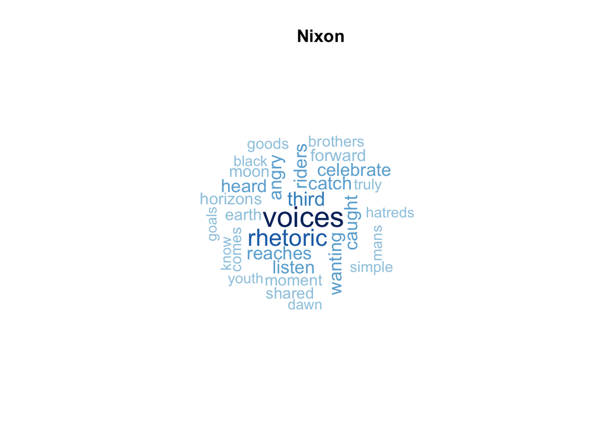

```r
wordcloud(tdm.nixon$term, tdm.nixon$count,
          scale=c(2,0.5),
          max.words=30,
          min.freq=1,
          random.order=FALSE,
          rot.per=0.3,
          use.r.layout=T,
          random.color=FALSE,
          colors=brewer.pal(9,"Blues"))
title(main = 'Nixon')
```

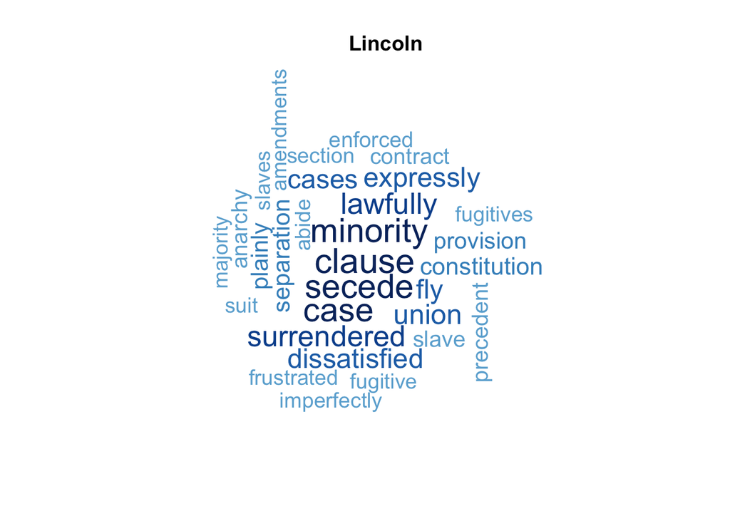

```r
wordcloud(tdm.lincoln$term, tdm.lincoln$count,
          scale=c(2,0.5),
          max.words=30,
          min.freq=1,
          random.order=FALSE,
          rot.per=0.3,
          use.r.layout=T,
          random.color=FALSE,
          colors=brewer.pal(9,"Blues"))
title(main = 'Lincoln')
```

Analysis - From the wordcloud, we can see that Trump likes to use simple and straightforward words like “jobs”, “workers”, “factories”, “borders”, “dreams”. For the other three presidents, while Lincoln also used some simple and straightforward words like “union”, “minority”, “constitution”, Obama used lots of fancy and metaphorical words like “icy”, “journey”, “winter”, “storms”.

# 2. Do they like to use long or short sentences?

### Step 2-1. Generate list of sentences.

```r
sentence.list=NULL
for(i in 1:nrow(inaug.list[])){
  sentences=sent_detect(inaug.list$fulltext[i],
                        endmarks = c("?", ".", "!", "|",";"))
  if(length(sentences)>0){
    emotions=get_nrc_sentiment(sentences)
    word.count=word_count(sentences)
    # colnames(emotions)=paste0("emo.", colnames(emotions))
    # in case the word counts are zeros?
    emotions=diag(1/(word.count+0.01))%*%as.matrix(emotions)
    sentence.list=rbind(sentence.list,
                        cbind(inaug.list[i,-ncol(inaug.list)],
                              sentences=as.character(sentences),
                              word.count,
                              emotions,
                              sent.id=1:length(sentences)
                              )
    )
  }
}
```

### Step 2-2. Some non-sentences exist in raw data due to erroneous extra end-of sentence marks.

```r
sentence.list=
  sentence.list%>%
  filter(!is.na(word.count))
```

### Step 2-3. Beeswarm - Visualize length of sentences.

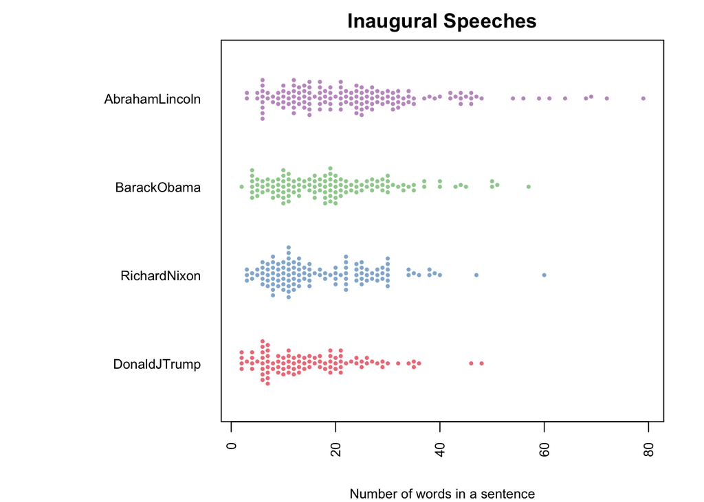

```r
sel.comparison=c("DonaldJTrump","BarackObama","RichardNixon", "AbrahamLincoln")

sentence.list.sel=sentence.list%>%filter(type=="inaug", File%in%sel.comparison, Term==1)
sentence.list.sel$File=factor(sentence.list.sel$File)

sentence.list.sel$FileOrdered=reorder(sentence.list.sel$File,
                                  sentence.list.sel$word.count,
                                  mean,
                                  order=T)
par(mar=c(4, 11, 2, 2))

beeswarm(word.count~FileOrdered,
         data=sentence.list.sel,
         horizontal = TRUE,
         pch=16, col=alpha(brewer.pal(9, "Set1"), 0.6),
         cex=0.55, cex.axis=0.8, cex.lab=0.8,
         spacing=5/nlevels(sentence.list.sel$FileOrdered),
         las=2, ylab="", xlab="Number of words in a sentence",
         main="Inaugural Speeches")
```

Analysis - From the beeswarm plot, we can see that Trump has the lowest average number of words in a sentence. He likes to use relatively short sentences, some of which are extremely short. For the other three presidents, while Nixon also used lots of short sentences, Lincoln used some short sentences but also included some very long sentences in his speech.

### Step 2-4. What are these short sentences?

```r
sentence.list%>%
  filter(File=="DonaldJTrump",
         type=="inaug",
         word.count<=3)%>%
  select(sentences)
```

```
##            sentences
## 1         Thank you.
## 2     America first.
## 3         Thank you.
## 4         Thank you.
## 5 God bless America.
```

```r
sentence.list%>%
  filter(File=="BarackObama",
         type=="inaug",
         word.count<=3)%>%
  select(sentences)
```

```
##                 sentences
## 1              Thank you.
## 2              Thank you.
## 3 diversity and openness;
## 4              Thank you.
```

```r
sentence.list%>%
  filter(File=="RichardNixon",
         type=="inaug",
         word.count<=3)%>%
  select(sentences)
```

```
##              sentences
## 1 Senator Dirksen, Mr.
## 2   Chief Justice, Mr.
## 3      I know America.
## 4                  Mr.
## 5  Vice President, Mr.
## 6         Speaker, Mr.
```

```r
sentence.list%>%
  filter(File=="AbrahamLincoln",
         type=="inaug",
         word.count<=3)%>%
  select(sentences)
```

```
##                  sentences
## 1             I think not.
## 2 Unanimity is impossible.
```

# 3. How do they shift between different sentiments in their speeches?

### Step 3-1. Sentence length variation over the course of the speech, with emotions.

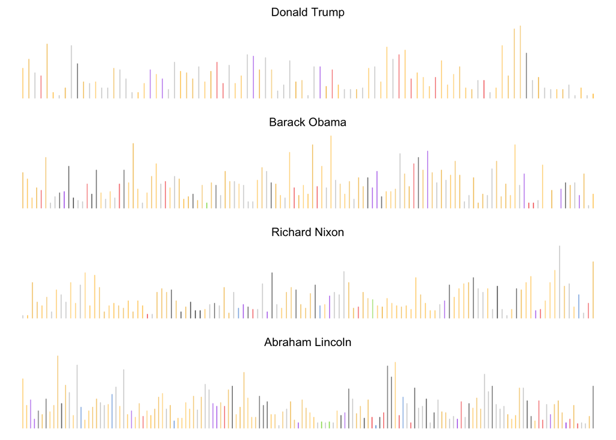

```r
par(mfrow=c(4,1), mar=c(1,0,2,0), bty="n", xaxt="n", yaxt="n", font.main=1)

f.plotsent.len(In.list=sentence.list, InFile="DonaldJTrump",
               InType="inaug", InTerm=1, President="Donald Trump")

f.plotsent.len(In.list=sentence.list, InFile="BarackObama",
               InType="inaug", InTerm=1, President="Barack Obama")

f.plotsent.len(In.list=sentence.list, InFile="RichardNixon",
               InType="inaug", InTerm=1, President="Richard Nixon")

f.plotsent.len(In.list=sentence.list, InFile="AbrahamLincoln",
               InType="inaug", InTerm=1, President="Abraham Lincoln")
```

Analysis - From the bar chart, we can see that Trump likes to use short sentences to convey simple and positive emotions. For the other three presidents, while Nixon’s speech is the most similar to Trump’s speech, Lincoln used longer sentences to convey more complicated emotions.

### Step 3-2. What are the emotionally charged sentences?

```r
print("Donald Trump")
```

```
## [1] "Donald Trump"
```

```r
speech.df=tbl_df(sentence.list)%>%
  filter(File=="DonaldJTrump", type=="inaug", Term==1, word.count>=5)%>%
  select(sentences, anger:trust)
speech.df=as.data.frame(speech.df)
as.character(speech.df$sentences[apply(speech.df[,-1], 2, which.max)])
```

```
## [1] "No challenge can match the heart and fight and spirit of America."
## [2] "God bless you, and God bless America."
## [3] "America will start winning again, winning like never before."
## [4] "No challenge can match the heart and fight and spirit of America."
## [5] "Today's ceremony, however, has very special meaning."
## [6] "America will start winning again, winning like never before."
## [7] "Today's ceremony, however, has very special meaning."
## [8] "God bless you, and God bless America."
```

```r
print("Barack Obama")
```

```
## [1] "Barack Obama"
```

```r
speech.df=tbl_df(sentence.list)%>%
  filter(File=="BarackObama", type=="inaug", Term==1, word.count>=5)%>%
  select(sentences, anger:trust)
speech.df=as.data.frame(speech.df)
as.character(speech.df$sentences[apply(speech.df[,-1], 2, which.max)])
```

```
## [1] "On this day, we gather because we have chosen hope over fear, unity of purpose over conflict and discord."
## [2] "This is the journey we continue today."
## [3] "We remain the most prosperous, powerful nation on Earth."
## [4] "Our Nation is at war against a far-reaching network of violence and hatred."
## [5] "We remain the most prosperous, powerful nation on Earth."
## [6] "Our Nation is at war against a far-reaching network of violence and hatred."
## [7] "This is the meaning of our liberty and our creed;"
## [8] "God bless you, and God bless the United States of America."
```

```r
print("Richard Nixon")
```

```
## [1] "Richard Nixon"
```

```r
speech.df=tbl_df(sentence.list)%>%
  filter(File=="RichardNixon", type=="inaug", Term==1, word.count>=5)%>%
  select(sentences, anger:trust)
speech.df=as.data.frame(speech.df)
as.character(speech.df$sentences[apply(speech.df[,-1], 2, which.max)])
```

```
## [1] "reaching with magnificent precision for the moon, but failing into raucous discord on earth."
## [2] "We see the hope of tomorrow in the youth of today."
## [3] "from angry rhetoric that fans discontents into hatreds;"
## [4] "In these difficult years, America has suffered from a fever of words;"
## [5] "Greatness comes in simple trappings."
## [6] "I have seen the hunger of a homeless child, the pain of a man wounded in battle, the grief of a mother who has lost her son."
## [7] "Greatness comes in simple trappings."
## [8] "We have learned at last to manage a modern economy to assure its continued growth."
```

```r
print("Abraham Lincoln")
```

```
## [1] "Abraham Lincoln"
```

```r
speech.df=tbl_df(sentence.list)%>%
  filter(File=="AbrahamLincoln", type=="inaug", Term==1, word.count>=5)%>%
  select(sentences, anger:trust)
speech.df=as.data.frame(speech.df)
as.character(speech.df$sentences[apply(speech.df[,-1], 2, which.max)])
```

```
## [1] "Whoever rejects it does of necessity fly to anarchy or to despotism."
## [2] "In our present differences, is either party without faith of being in the right?"
## [3] "'May' Congress prohibit slavery in the Territories?"
## [4] "The Government will not assail 'you'."
## [5] "Though passion may have strained it must not break our bonds of affection."
## [6] "Whoever rejects it does of necessity fly to anarchy or to despotism."
## [7] "The Government will not assail 'you'."
## [8] "Perpetuity is implied, if not expressed, in the fundamental law of all national governments."
```

### Step 3-3. Bar Chart - Visualize clustering of emotions.

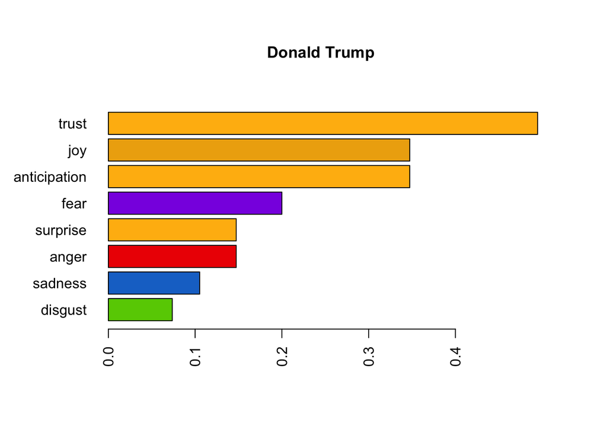

```r
sel.comparison=c("DonaldJTrump","BarackObama","RichardNixon","AbrahamLincoln")

par(mar=c(6, 6, 6, 4))
emo.means=colMeans(select(sentence.list%>%filter(type=="inaug", File=='DonaldJTrump'), anger:trust)>0.01)
col.use=c("red2", "darkgoldenrod1",
            "chartreuse3", "blueviolet",
            "darkgoldenrod2", "dodgerblue3",
            "darkgoldenrod1", "darkgoldenrod1")
barplot(emo.means[order(emo.means)], las=2, col=col.use[order(emo.means)], horiz=T, main="Donald Trump", cex.main = 1.1)
```

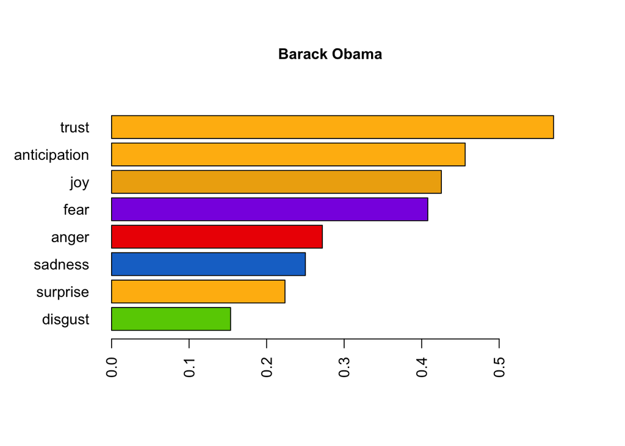

```r
par(mar=c(6, 6, 6, 4))
emo.means=colMeans(select(sentence.list%>%filter(type=="inaug", File=="BarackObama"), anger:trust)>0.01)
col.use=c("red2", "darkgoldenrod1",
            "chartreuse3", "blueviolet",
            "darkgoldenrod2", "dodgerblue3",
            "darkgoldenrod1", "darkgoldenrod1")
barplot(emo.means[order(emo.means)], las=2, col=col.use[order(emo.means)], horiz=T, main="Barack Obama", cex.main = 1)
```

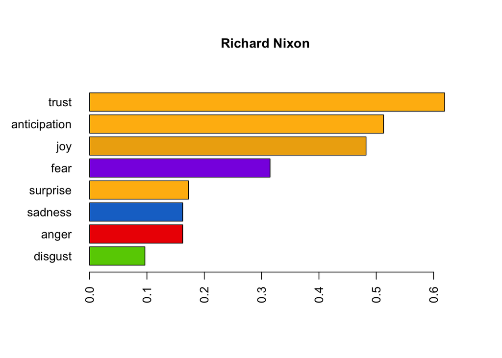

```r
par(mar=c(6, 6, 6, 4))
emo.means=colMeans(select(sentence.list%>%filter(type=="inaug", File=="RichardNixon"), anger:trust)>0.01)
col.use=c("red2", "darkgoldenrod1",
            "chartreuse3", "blueviolet",
            "darkgoldenrod2", "dodgerblue3",
            "darkgoldenrod1", "darkgoldenrod1")
barplot(emo.means[order(emo.means)], las=2, col=col.use[order(emo.means)], horiz=T, main="Richard Nixon", cex.main = 1.1)
```

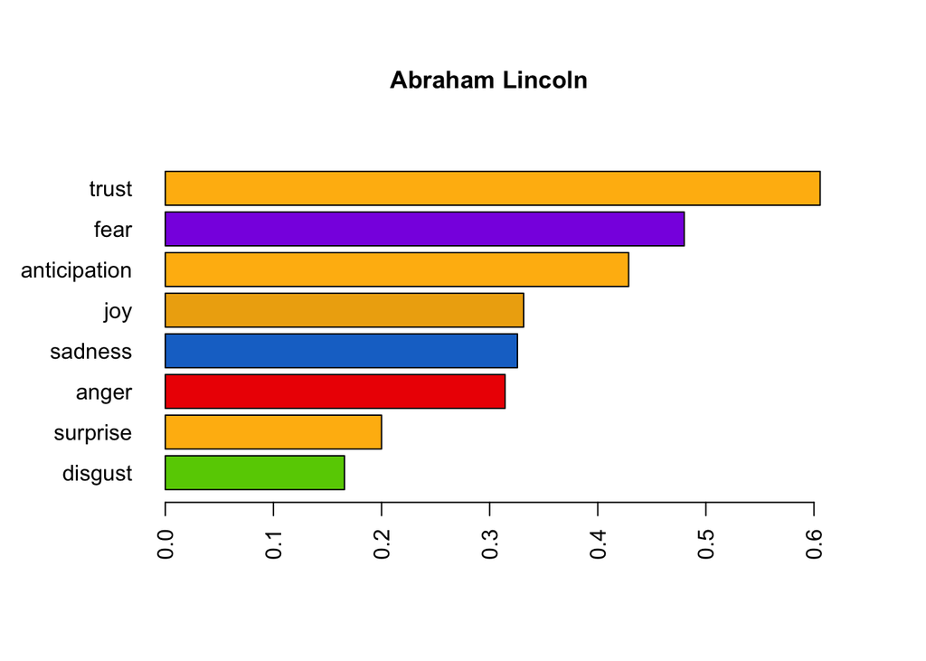

```r
par(mar=c(6, 6, 6, 4))
emo.means=colMeans(select(sentence.list%>%filter(type=="inaug", File=='AbrahamLincoln'), anger:trust)>0.01)
col.use=c("red2", "darkgoldenrod1",
            "chartreuse3", "blueviolet",
            "darkgoldenrod2", "dodgerblue3",
            "darkgoldenrod1", "darkgoldenrod1")
barplot(emo.means[order(emo.means)], las=2, col=col.use[order(emo.means)], horiz=T, main="Abraham Lincoln", cex.main = 1.1)
```

Analysis - From the bar chart we can see that, with “trust”, “joy”, and “anticipation” being the top three emotions, Trump’s speech is generally very positive. Even though his strongest negative emotion is “fear”, it is the lowest (0.2) among these four presidents. For the other three presidents, while Nixon’s speech shares some similarities with Trump’s speech, Lincoln’s speech has very strong “fear” emotion (0.5). At the same time, historical context needs to be taken into consideration when analyzing emotions of speeches.

# 4. How do they alternate between different topics?

### Step 4-1. Prepare a corpus of sentence snipets as follows. For each speech, start with sentences and prepare a snipet with a given sentence with the flanking sentences.

```r
corpus.list=sentence.list[2:(nrow(sentence.list)-1), ]
sentence.pre=sentence.list$sentences[1:(nrow(sentence.list)-2)]
sentence.post=sentence.list$sentences[3:(nrow(sentence.list)-1)]
corpus.list$snipets=paste(sentence.pre, corpus.list$sentences, sentence.post, sep=" ")
rm.rows=(1:nrow(corpus.list))[corpus.list$sent.id==1]
rm.rows=c(rm.rows, rm.rows-1)
corpus.list=corpus.list[-rm.rows, ]
```

### Step 4-2. Text mining.

```r
docs <- Corpus(VectorSource(corpus.list$snipets))
writeLines(as.character(docs[[sample(1:nrow(corpus.list), 1)]]))
```

```
## These persons inculcate a sanctimonious reverence for the customs of their ancestors; that whatsoever they did must be done through all time; that reason is a false guide, and to advance under its counsel in their physical, moral, or political condition is perilous innovation;
```

### Step 4-3. Text processing.

```r
#remove potentially problematic symbols
docs <-tm_map(docs,content_transformer(tolower))
writeLines(as.character(docs[[sample(1:nrow(corpus.list), 1)]]))
```

```
## but it should be so conducted that all the world may see in it, not a menace, but an instrument of security and peace. this nation believes thoroughly in an honorable peace under which the rights of its citizens are to be everywhere protected. it has never found that the necessary enjoyment of su…
```

```r
#remove punctuation
docs <- tm_map(docs, removePunctuation)
writeLines(as.character(docs[[sample(1:nrow(corpus.list), 1)]]))
```

```
## built new structures on enduring lines and through it all maintained the fact of its democracy for action has been taken within the threeway framework of the constitution of the united states
```

```r
#Strip digits
docs <- tm_map(docs, removeNumbers)
writeLines(as.character(docs[[sample(1:nrow(corpus.list), 1)]]))
```

```
## party exasperation has been often carried to its highest point the virtue and fortitude of the people have sometimes been greatly tried yet our system purified and enhanced in value by all it has encountered still preserves its spirit of free and fearless discussion blended with unimpaired frater…
```

```r
#remove stopwords
docs <- tm_map(docs, removeWords, stopwords("english"))
writeLines(as.character(docs[[sample(1:nrow(corpus.list), 1)]]))
```

```
##    composite  cosmopolitan people     blood    nations    war  currents   thoughts  well   currents   trade run quick   seasons back  forth  us
```

```r
#remove whitespace
docs <- tm_map(docs, stripWhitespace)
writeLines(as.character(docs[[sample(1:nrow(corpus.list), 1)]]))
```

```
##  possible adjustment made purchasing power every coined dollar will exactly equal debtpaying power markets world chief duty national government connection currency country coin money declare value grave doubts entertained whether congress authorized constitution make form paper money legal tender
```

```r
#Stem document
docs <- tm_map(docs,stemDocument)
writeLines(as.character(docs[[sample(1:nrow(corpus.list), 1)]]))
```

```
## us now must done us go forward program aim reach balanc budget
```

### Step 4-4. Gengerate document-term matrices.

```r
dtm <- DocumentTermMatrix(docs)
#convert rownames to filenames#convert rownames to filenames
rownames(dtm) <- paste(corpus.list$type, corpus.list$File,
                       corpus.list$Term, corpus.list$sent.id, sep="_")

rowTotals <- apply(dtm , 1, sum) #Find the sum of words in each Document

dtm  <- dtm[rowTotals> 0, ]
corpus.list=corpus.list[rowTotals>0, ]
```

### Step 4-5. Run LDA.

```r
#Set parameters for Gibbs sampling
burnin <- 4000
iter <- 2000
thin <- 500
seed <-list(2003,5,63,100001,765)
nstart <- 5
best <- TRUE

#Number of topics
k <- 15

#Run LDA using Gibbs sampling
ldaOut <-LDA(dtm, k, method="Gibbs", control=list(nstart=nstart,
                                                 seed = seed, best=best,
                                                 burnin = burnin, iter = iter,
                                                 thin=thin))
#write out results
#docs to topics
ldaOut.topics <- as.matrix(topics(ldaOut))
table(c(1:k, ldaOut.topics))
```

```
##
##   1   2   3   4   5   6   7   8   9  10  11  12  13  14  15
## 566 563 367 388 444 459 296 295 356 342 339 283 258 288 302
```

```r
write.csv(ldaOut.topics,file=paste("../out/LDAGibbs",k,"DocsToTopics.csv"))

#top 6 terms in each topic
ldaOut.terms <- as.matrix(terms(ldaOut,20))
write.csv(ldaOut.terms,file=paste("../out/LDAGibbs",k,"TopicsToTerms.csv"))

#probabilities associated with each topic assignment
topicProbabilities <- as.data.frame(ldaOut@gamma)
write.csv(topicProbabilities,file=paste("../out/LDAGibbs",k,"TopicProbabilities.csv"))
```

```r
terms.beta=ldaOut@beta
terms.beta=scale(terms.beta)
topics.terms=NULL
for(i in 1:k){
  topics.terms=rbind(topics.terms, ldaOut@terms[order(terms.beta[i,], decreasing = TRUE)[1:7]])
}
topics.terms
```

```
##       [,1]         [,2]      [,3]        [,4]        [,5]
##  [1,] "heart"      "word"    "moment"    "thank"     "ancient"
##  [2,] "old"        "build"   "show"      "role"      "everyon"
##  [3,] "defens"     "treati"  "engag"     "proof"     "river"
##  [4,] "centuri"    "problem" "address"   "weve"      "happen"
##  [5,] "major"      "amend"   "deliber"   "prohibit"  "elector"
##  [6,] "mankind"    "program" "everywher" "dark"      "goal"
##  [7,] "obtain"     "purchas" "amic"      "equival"   "belliger"
##  [8,] "anyth"      "obstacl" "nobil"     "tyrant"    "doom"
##  [9,] "revenu"     "money"   "credit"    "adequ"     "wast"
## [10,] "perform"    "appoint" "discharg"  "zeal"      "shrink"
## [11,] "grant"      "perpetu" "separ"     "compromis" "defect"
## [12,] "endang"     "destin"  "outset"    "collis"    "roman"
## [13,] "intellig"   "spring"  "inherit"   "profess"   "genuin"
## [14,] "agricultur" "market"  "farm"      "rate"      "restrict"
```

[output cut: 17 more lines]

```r
ldaOut.terms
```

```
##       Topic 1   Topic 2    Topic 3     Topic 4   Topic 5      Topic 6
##  [1,] "day"     "will"     "war"       "now"     "law"        "world"
##  [2,] "man"     "new"      "great"     "time"    "upon"       "freedom"
##  [3,] "stand"   "america"  "unit"      "year"    "parti"      "peac"
##  [4,] "hand"    "american" "state"     "great"   "congress"   "nation"
##  [5,] "presid"  "let"      "made"      "chang"   "constitut"  "free"
##  [6,] "god"     "make"     "forc"      "come"    "execut"     "human"
##  [7,] "faith"   "togeth"   "territori" "futur"   "question"   "hope"
##  [8,] "today"   "old"      "extend"    "thing"   "legisl"     "help"
##  [9,] "first"   "respons"  "defens"    "centuri" "may"        "strength"
## [10,] "heart"   "promis"   "part"      "still"   "effect"     "seek"
## [11,] "histori" "better"   "sinc"      "continu" "elect"      "secur"
## [12,] "time"    "bring"    "countri"   "last"    "subject"    "democraci"
## [13,] "place"   "work"     "arm"       "believ"  "control"    "know"
## [14,] "just"    "ideal"    "popul"     "look"    "enforc"     "strong"
```

[output cut: 48 more lines]

### Step 4-6. Based on the most popular terms and the most salient terms for each topic, assign a hashtag to each topic.

```r
topics.hash=c("Economy", "America", "Defense", "Belief", "Election", "Patriotism", "Unity", "Government", "Reform", "Temporal", "WorkingFamilies", "Freedom", "Equality", "Misc", "Legislation")
corpus.list$ldatopic=as.vector(ldaOut.topics)
corpus.list$ldahash=topics.hash[ldaOut.topics]

colnames(topicProbabilities)=topics.hash
corpus.list.df=cbind(corpus.list, topicProbabilities)
```

### Step 4-7. Heatmap - Visualize clustering of topics.

```r
par(mar=c(1,1,1,1))
topic.summary=tbl_df(corpus.list.df)%>%
              filter(type%in%c("nomin", "inaug"), File%in%sel.comparison)%>%
              select(File, Economy:Legislation)%>%
              group_by(File)%>%
              summarise_each(funs(mean))
```

```
## `summarise_each()` is deprecated.
## Use `summarise_all()`, `summarise_at()` or `summarise_if()` instead.
## To map `funs` over all variables, use `summarise_all()`
```

```r
topic.summary=as.data.frame(topic.summary)
rownames(topic.summary)=topic.summary[,1]

# [1] "Economy"         "America"         "Defense"         "Belief"
# [5] "Election"        "Patriotism"      "Unity"           "Government"
# [9] "Reform"          "Temporal"        "WorkingFamilies" "Freedom"
# [13] "Equality"        "Misc"            "Legislation"

topic.plot=c(1, 13, 9, 11, 8, 3, 7)
print(topics.hash[topic.plot])
```

```
## [1] "Economy"         "Equality"        "Reform"          "WorkingFamilies"
## [5] "Government"      "Defense"         "Unity"
```

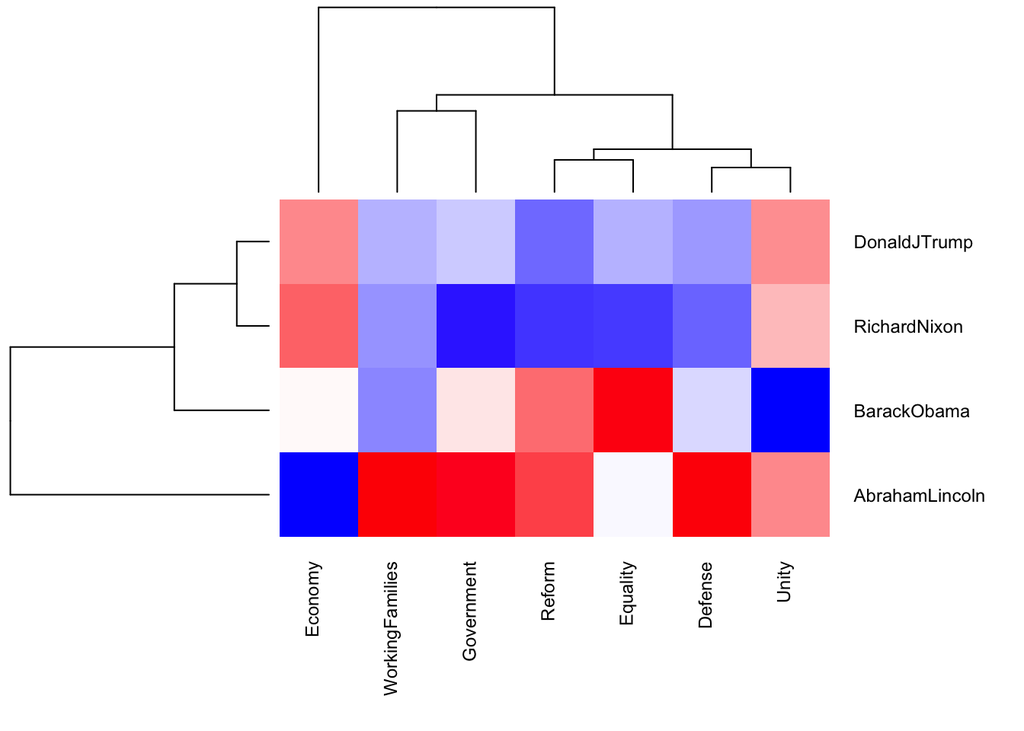

```r
heatmap.2(as.matrix(topic.summary[,topic.plot+1]),
          scale = "column", key=F,
          col = bluered(100),
          cexRow = 0.9, cexCol = 0.9, margins = c(8, 8),
          trace = "none", density.info = "none")
```

Analysis - From the heatmap, we can see that Trump likes to talk about “Unity” and “Economy” the most, and he doesn’t seem to care about “Reform” or “Defense” too much. For the other three presidents, while, surprisingly, Nixon’s focuses in his speech are almost exactly the same with Trump’s, Lincoln and Trump are almost the opposite since Lincoln cared a lot about “Defense”, “Reform”, “WorkingFamilies”, “Government”, which are all barely mentioned in Trump’s speech.

### Step 4-7. Stacked line plot - Visualize clustering of topics.

```r
# [1] "Economy"         "America"         "Defense"         "Belief"
# [5] "Election"        "Patriotism"      "Unity"           "Government"
# [9] "Reform"          "Temporal"        "WorkingFamilies" "Freedom"
# [13] "Equality"        "Misc"            "Legislation"


par(mfrow=c(5, 1), mar=c(1,1,2,0), bty="n", xaxt="n", yaxt="n")

topic.plot=c(1, 13, 14, 15, 8, 9, 12)
print(topics.hash[topic.plot])
```

```
## [1] "Economy"     "Equality"    "Misc"        "Legislation" "Government"
## [6] "Reform"      "Freedom"
```

```r
speech.df=tbl_df(corpus.list.df)%>%filter(File=="DonaldJTrump", type=="inaug", Term==1)%>%select(sent.id, Economy:Legislation)
speech.df=as.matrix(speech.df)
speech.df[,-1]=replace(speech.df[,-1], speech.df[,-1]<1/15, 0.001)
speech.df[,-1]=f.smooth.topic(x=speech.df[,1], y=speech.df[,-1])
plot.stacked(speech.df[,1], speech.df[,topic.plot+1],
            xlab="Sentences", ylab="Topic share", main="Donald Trump")
```

```
## [1] 0.06039268 0.12078537 0.18117805 0.24157074 0.30196342 0.36235610
## [7] 0.42274879
```

```r
speech.df=tbl_df(corpus.list.df)%>%filter(File=="BarackObama", type=="inaug", Term==1)%>%select(sent.id, Economy:Legislation)
speech.df=as.matrix(speech.df)
speech.df[,-1]=replace(speech.df[,-1], speech.df[,-1]<1/15, 0.001)
speech.df[,-1]=f.smooth.topic(x=speech.df[,1], y=speech.df[,-1])
plot.stacked(speech.df[,1], speech.df[,topic.plot+1],
            xlab="Sentences", ylab="Topic share", main="Barack Obama")
```

```
## [1] 0.07101842 0.14203684 0.21305526 0.28407368 0.35509210 0.42611052
## [7] 0.49712894
```

```r
speech.df=tbl_df(corpus.list.df)%>%filter(File=="RichardNixon", type=="inaug",Term==1)%>%select(sent.id, Economy:Legislation)
speech.df=as.matrix(speech.df)
speech.df[,-1]=replace(speech.df[,-1], speech.df[,-1]<1/15, 0.001)
speech.df[,-1]=f.smooth.topic(x=speech.df[,1], y=speech.df[,-1])
plot.stacked(speech.df[,1], speech.df[,topic.plot+1],
             xlab="Sentences", ylab="Topic share", main="Richard Nixon")
```

```
## [1] 0.06482254 0.12964507 0.19446761 0.25929015 0.32411268 0.38893522
## [7] 0.45375776
```

```
## [1] 0.05423998 0.10847996 0.16271993 0.21695991 0.27119989 0.32543987
## [7] 0.37967985
```

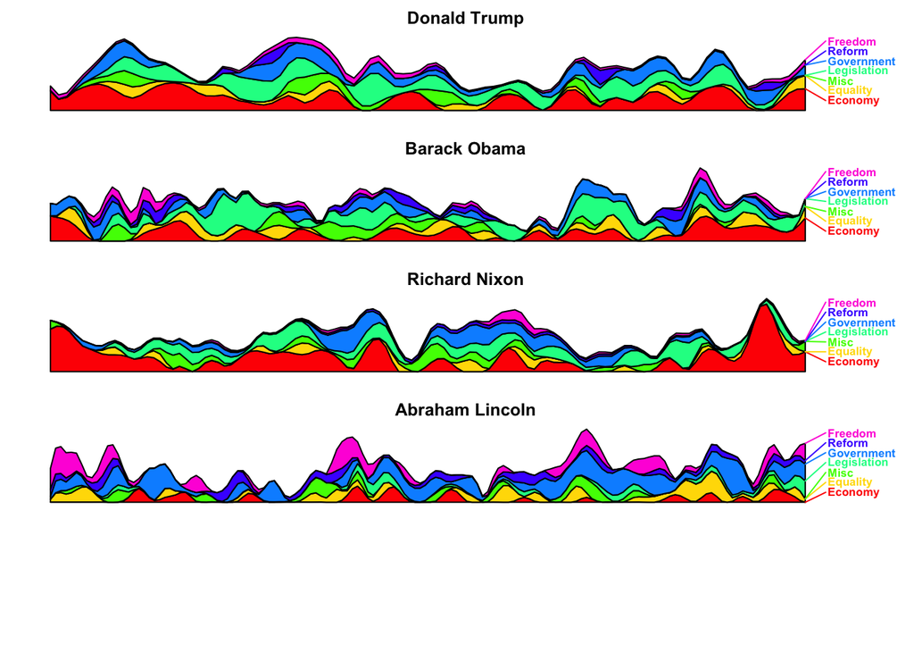

```r
speech.df=tbl_df(corpus.list.df)%>%filter(File=="AbrahamLincoln", type=="inaug", Term==1)%>%select(sent.id, Economy:Legislation)
speech.df=as.matrix(speech.df)
speech.df[,-1]=replace(speech.df[,-1], speech.df[,-1]<1/15, 0.001)
speech.df[,-1]=f.smooth.topic(x=speech.df[,1], y=speech.df[,-1])
plot.stacked(speech.df[,1], speech.df[,topic.plot+1],
            xlab="Sentences", ylab="Topic share", main="Abraham Lincoln")
```

Analysis - From the stacked line plot, we can see that Trump emphasizes on “Economy” and “Legislation” all along his speech. For the other three presidents, while Nixon also emphasized a lot on “Economy” and “Legislation”, Lincoln didn’t focus on “Economy” or “Legislation” that much but talked a lot about “Government” and “Freedom” instead.

# Conclusion

In this report, I compared Trump to three past presidents of the United States, Nixon, Lincoln, and Obama to see who is Trump most like from a linguistic perspective. I explored the texts of their inaugural speeches by analyzing their most frequent words, typical sentence length, strongest emotions, and most mentioned topics with text mining and natural language processing techniques. In conclusion, we can see that Trump is most like Nixon when it comes to inaugural speeches since they both use shorter sentences, convey mostly positive emotions and care about economy and unity the most.